# Lab 4 - Coffee Lovers Unite

# Scrape the Location Counts

### The menuism website has been down all week, so I am using someone’s csv file where they have scraped all of the data already. This csv file is from Joe on Discord.

### I am using Kevin Nagpal’s code for the webscraping section, since I did not have the chance to try it myself before the website went down.

```python
import requests
import pandas as pd
from bs4 import BeautifulSoup
import re
from plotnine import *

#!pip install us (package specifically dealing with US states and other details)
import us #source: https://pypi.org/project/us/
```

```python
# starbucks

response_starbucks = requests.get("https://www.menuism.com/restaurant-locations/starbucks-coffee-39564")

soup_star = BeautifulSoup(response_starbucks.content, "html.parser")

# Finding All US Stores
stores_star = soup_star.find_all("li",
                        attrs={"class": ""})

# Creating For Loop that Goes Through Each Store
rows_starbucks = []

for store in stores_star:

    # Adjusting for Content not containing Titles or Relevant Keys
    if store.find("a") != None:
        cells = store.find("a")

        if cells.get('title') != None:
            loc_tag = cells.get('title')

            # Filtering Just to US Locations
            if loc_tag[-2:] == "us" and loc_tag[-6:-4] != "dc":

              # Find the name of the State
                store_tag = cells.get_text()

              # Creating List of Store Tag to Obtain State Name
                tag_list = store_tag.split(" ")

                states_list = ['Dakota','Carolina','Hampshire','York','Jersey','Mexico','Island','Virginia']
                if tag_list[1] not in states_list:
                    state_name = tag_list[0]

                else:
                    state_name = " ".join(tag_list[0:2])

                store_locations = re.findall(r'\((.*?)\)', store_tag)[0] # Locations In Between Parentheses
                store_locations = pd.to_numeric(store_locations) # Converting to Integers

              # Obtaining Store Name from URL
                pattern = r'/([^/]+)$'
                store_name = re.findall(pattern, url_dd)[0]

              # Append this data.
                rows_starbucks.append({
                    "State": state_name,
                    store_name:store_locations
                })

# Converting Rows to Dataframe
starbucks_df = pd.DataFrame(rows_starbucks)
# Confirming Webscraping Worked
starbucks_df.head()
```

```
SyntaxError: invalid non-printable character U+00A0 (2609842468.py, line 9)
```

```python
# Dunkin' Donuts

response_dd = requests.get("https://www.menuism.com/restaurant-locations/dunkin-donuts")

soup_dd = BeautifulSoup(response_dd.content, "html.parser")

# Finding All US Stores
stores_dd = soup_dd.find_all("li",
                        attrs=
                         {"class": ""})

# Creating For Loop that Goes Through Each Store
rows_dd = []

for store in stores_dd:

    # Adjusting for Content not containing Titles or Relevant Keys
    if store.find("a") != None:
        cells = store.find("a")

        if cells.get('title') != None:
            loc_tag = cells.get('title')

            # Filtering Just to US Locations
            if loc_tag[-2:] == "us" and loc_tag[-6:-4] != "dc":

              # Find the name of the State
                store_tag = cells.get_text()

              # Creating List of Store Tag to Obtain State Name
                tag_list = store_tag.split(" ")

                states_list = ['Dakota','Carolina','Hampshire','York','Jersey','Mexico','Island','Virginia']
                if tag_list[1] not in states_list:
                    state_name = tag_list[0]

                else:
                    state_name = " ".join(tag_list[0:2])

                store_locations = re.findall(r'\((.*?)\)', store_tag)[0] # Locations In Between Parentheses
                store_locations = pd.to_numeric(store_locations) # Converting to Integers

              # Obtaining Store Name from URL
                pattern = r'/([^/]+)$'
                store_name = re.findall(pattern, url_dd)[0]

              # Append this data.
                rows_dd.append({
                    "State": state_name,
                    store_name:store_locations
                })

# Converting Rows to Dataframe
dd_df = pd.DataFrame(rows_dd)
# Confirming Webscraping Worked
dd_df.head()
```

```python
# Peet's coffee & tea

response_peet = requests.get("https://www.menuism.com/restaurant-locations/starbucks-coffee-39564")

soup_peet = BeautifulSoup(response_peet.content, "html.parser")

# Finding All US Stores
stores_peet = soup_peet.find_all("li",
                        attrs=
                         {"class": ""})

# Creating For Loop that Goes Through Each Store
rows_peet = []

for store in stores_peet:

    # Adjusting for Content not containing Titles or Relevant Keys
    if store.find("a") != None:
        cells = store.find("a")

        if cells.get('title') != None:
            loc_tag = cells.get('title')

            # Filtering Just to US Locations
            if loc_tag[-2:] == "us" and loc_tag[-6:-4] != "dc":

              # Find the name of the State
                store_tag = cells.get_text()

              # Creating List of Store Tag to Obtain State Name
                tag_list = store_tag.split(" ")

                states_list = ['Dakota','Carolina','Hampshire','York','Jersey','Mexico','Island','Virginia']
                if tag_list[1] not in states_list:
                    state_name = tag_list[0]

                else:
                    state_name = " ".join(tag_list[0:2])

                store_locations = re.findall(r'\((.*?)\)', store_tag)[0] # Locations In Between Parentheses
                store_locations = pd.to_numeric(store_locations) # Converting to Integers

              # Obtaining Store Name from URL
                pattern = r'/([^/]+)$'
                store_name = re.findall(pattern, url_dd)[0]

              # Append this data.
                rows_peet.append({
                    "State": state_name,
                    store_name:store_locations
                })

# Converting Rows to Dataframe
peet_df = pd.DataFrame(rows_peet)
# Confirming Webscraping Worked
peet_df.head()
```

```python
# Tim Hortons

response_th = requests.get("https://www.menuism.com/restaurant-locations/starbucks-coffee-39564")

soup_th = BeautifulSoup(response_th.content, "html.parser")

# Finding All US Stores
stores_th = soup_th.find_all("li",
                        attrs=
                         {"class": ""})

# Creating For Loop that Goes Through Each Store
rows_th = []

for store in stores_th:

    # Adjusting for Content not containing Titles or Relevant Keys
    if store.find("a") != None:
        cells = store.find("a")

        if cells.get('title') != None:
            loc_tag = cells.get('title')

            # Filtering Just to US Locations
            if loc_tag[-2:] == "us" and loc_tag[-6:-4] != "dc":

              # Find the name of the State
                store_tag = cells.get_text()

              # Creating List of Store Tag to Obtain State Name
                tag_list = store_tag.split(" ")

                states_list = ['Dakota','Carolina','Hampshire','York','Jersey','Mexico','Island','Virginia']
                if tag_list[1] not in states_list:
                    state_name = tag_list[0]

                else:
                    state_name = " ".join(tag_list[0:2])

                store_locations = re.findall(r'\((.*?)\)', store_tag)[0] # Locations In Between Parentheses
                store_locations = pd.to_numeric(store_locations) # Converting to Integers

              # Obtaining Store Name from URL
                pattern = r'/([^/]+)$'
                store_name = re.findall(pattern, url_dd)[0]

              # Append this data.
                rows_th.append({
                    "State": state_name,
                    store_name:store_locations
                })

# Converting Rows to Dataframe
th_df = pd.DataFrame(rows_th)
# Confirming Webscraping Worked
th_df.head()
```

```python
# Panera Bread

response_pb = requests.get("https://www.menuism.com/restaurant-locations/starbucks-coffee-39564")

soup_pb = BeautifulSoup(response_starbucks.content, "html.parser")

# Finding All US Stores
stores_pb = soup_pb.find_all("li",
                        attrs=
                         {"class": ""})

# Creating For Loop that Goes Through Each Store
rows_pb = []

for store in stores_pb:

    # Adjusting for Content not containing Titles or Relevant Keys
    if store.find("a") != None:
        cells = store.find("a")

        if cells.get('title') != None:
            loc_tag = cells.get('title')

            # Filtering Just to US Locations
            if loc_tag[-2:] == "us" and loc_tag[-6:-4] != "dc":

              # Find the name of the State
                store_tag = cells.get_text()

              # Creating List of Store Tag to Obtain State Name
                tag_list = store_tag.split(" ")

                states_list = ['Dakota','Carolina','Hampshire','York','Jersey','Mexico','Island','Virginia']
                if tag_list[1] not in states_list:
                    state_name = tag_list[0]

                else:
                    state_name = " ".join(tag_list[0:2])

                store_locations = re.findall(r'\((.*?)\)', store_tag)[0] # Locations In Between Parentheses
                store_locations = pd.to_numeric(store_locations) # Converting to Integers

              # Obtaining Store Name from URL
                pattern = r'/([^/]+)$'
                store_name = re.findall(pattern, url_dd)[0]

              # Append this data.
                rows_pb.append({
                    "State": state_name,
                    store_name:store_locations
                })

# Converting Rows to Dataframe
pb_df = pd.DataFrame(rows_pb)
# Confirming Webscraping Worked
pb_df.head()
```

```python
# Caribou Coffee

response_cc = requests.get("https://www.menuism.com/restaurant-locations/starbucks-coffee-39564")

soup_cc = BeautifulSoup(response_starbucks.content, "html.parser")

# Finding All US Stores
stores_cc = soup_cc.find_all("li",
                        attrs=
                         {"class": ""})

# Creating For Loop that Goes Through Each Store
rows_cc = []

for store in stores_cc:

    # Adjusting for Content not containing Titles or Relevant Keys
    if store.find("a") != None:
        cells = store.find("a")

        if cells.get('title') != None:
            loc_tag = cells.get('title')

            # Filtering Just to US Locations
            if loc_tag[-2:] == "us" and loc_tag[-6:-4] != "dc":

              # Find the name of the State
                store_tag = cells.get_text()

              # Creating List of Store Tag to Obtain State Name
                tag_list = store_tag.split(" ")

                states_list = ['Dakota','Carolina','Hampshire','York','Jersey','Mexico','Island','Virginia']
                if tag_list[1] not in states_list:
                    state_name = tag_list[0]

                else:
                    state_name = " ".join(tag_list[0:2])

                store_locations = re.findall(r'\((.*?)\)', store_tag)[0] # Locations In Between Parentheses
                store_locations = pd.to_numeric(store_locations) # Converting to Integers

              # Obtaining Store Name from URL
                pattern = r'/([^/]+)$'
                store_name = re.findall(pattern, url_dd)[0]

              # Append this data.
                rows_cc.append({
                    "State": state_name,
                    store_name:store_locations
                })

# Converting Rows to Dataframe
cc_df = pd.DataFrame(rows_cc)
# Confirming Webscraping Worked
cc_df.head()
```

```python
# Au Bon Pain

response_abp = requests.get("https://www.menuism.com/restaurant-locations/starbucks-coffee-39564")

soup_abp = BeautifulSoup(response_abp.content, "html.parser")

# Finding All US Stores
stores_abp = soup_abp.find_all("li",
                        attrs=
                         {"class": ""})

# Creating For Loop that Goes Through Each Store
rows_abp = []

for store in stores_abp:

    # Adjusting for Content not containing Titles or Relevant Keys
    if store.find("a") != None:
        cells = store.find("a")

        if cells.get('title') != None:
            loc_tag = cells.get('title')

            # Filtering Just to US Locations
            if loc_tag[-2:] == "us" and loc_tag[-6:-4] != "dc":

              # Find the name of the State
                store_tag = cells.get_text()

              # Creating List of Store Tag to Obtain State Name
                tag_list = store_tag.split(" ")

                states_list = ['Dakota','Carolina','Hampshire','York','Jersey','Mexico','Island','Virginia']
                if tag_list[1] not in states_list:
                    state_name = tag_list[0]

                else:
                    state_name = " ".join(tag_list[0:2])

                store_locations = re.findall(r'\((.*?)\)', store_tag)[0] # Locations In Between Parentheses
                store_locations = pd.to_numeric(store_locations) # Converting to Integers

              # Obtaining Store Name from URL
                pattern = r'/([^/]+)$'
                store_name = re.findall(pattern, url_dd)[0]

              # Append this data.
                rows_abp.append({
                    "State": state_name,
                    store_name:store_locations
                })

# Converting Rows to Dataframe
abp_df = pd.DataFrame(rows_abp)
# Confirming Webscraping Worked
abp_df.head()
```

```python
# The Coffee Bean & Tea Leaf

response_cbtl = requests.get("https://www.menuism.com/restaurant-locations/starbucks-coffee-39564")

soup_cbtl = BeautifulSoup(response_cbtl.content, "html.parser")

# Finding All US Stores
stores_cbtl = soup_cbtl.find_all("li",
                        attrs=
                         {"class": ""})

# Creating For Loop that Goes Through Each Store
rows_cbtl = []

for store in stores_cbtl:

    # Adjusting for Content not containing Titles or Relevant Keys
    if store.find("a") != None:
        cells = store.find("a")

        if cells.get('title') != None:
            loc_tag = cells.get('title')

            # Filtering Just to US Locations
            if loc_tag[-2:] == "us" and loc_tag[-6:-4] != "dc":

              # Find the name of the State
                store_tag = cells.get_text()

              # Creating List of Store Tag to Obtain State Name
                tag_list = store_tag.split(" ")

                states_list = ['Dakota','Carolina','Hampshire','York','Jersey','Mexico','Island','Virginia']
                if tag_list[1] not in states_list:
                    state_name = tag_list[0]

                else:
                    state_name = " ".join(tag_list[0:2])

                store_locations = re.findall(r'\((.*?)\)', store_tag)[0] # Locations In Between Parentheses
                store_locations = pd.to_numeric(store_locations) # Converting to Integers

              # Obtaining Store Name from URL
                pattern = r'/([^/]+)$'
                store_name = re.findall(pattern, url_dd)[0]

              # Append this data.
                rows_cbtl.append({
                    "State": state_name,
                    store_name:store_locations
                })

# Converting Rows to Dataframe
cbtl_df = pd.DataFrame(rows_cbtl)
# Confirming Webscraping Worked
cbtl_df.head()
```

```python
# McDonald's

response_md = requests.get("https://www.menuism.com/restaurant-locations/starbucks-coffee-39564")

soup_md = BeautifulSoup(response_md.content, "html.parser")

# Finding All US Stores
stores_md = soup_md.find_all("li",
                        attrs=
                         {"class": ""})

# Creating For Loop that Goes Through Each Store
rows_md = []

for store in stores_md:

    # Adjusting for Content not containing Titles or Relevant Keys
    if store.find("a") != None:
        cells = store.find("a")

        if cells.get('title') != None:
            loc_tag = cells.get('title')

            # Filtering Just to US Locations
            if loc_tag[-2:] == "us" and loc_tag[-6:-4] != "dc":

              # Find the name of the State
                store_tag = cells.get_text()

              # Creating List of Store Tag to Obtain State Name
                tag_list = store_tag.split(" ")

                states_list = ['Dakota','Carolina','Hampshire','York','Jersey','Mexico','Island','Virginia']
                if tag_list[1] not in states_list:
                    state_name = tag_list[0]

                else:
                    state_name = " ".join(tag_list[0:2])

                store_locations = re.findall(r'\((.*?)\)', store_tag)[0] # Locations In Between Parentheses
                store_locations = pd.to_numeric(store_locations) # Converting to Integers

              # Obtaining Store Name from URL
                pattern = r'/([^/]+)$'
                store_name = re.findall(pattern, url_dd)[0]

              # Append this data.
                rows_md.append({
                    "State": state_name,
                    store_name:store_locations
                })

# Converting Rows to Dataframe
md_df = pd.DataFrame(rows_md)
# Confirming Webscraping Worked
md_df.head()
```

```python
def stateabbr(state):
    """
    Outputs the state abbreviation when given the state full name
    case insensitive and spelling doesn't matter

    Parameter
    ---------
    state : str
    A string of the state name

    Returns
    -------
    str
    A string of the state abbreviation

    """
    state_name = us.states.lookup(state)
    if state_name is not None:
        return state_name.abbr
    else:
        return "State not found"



#stateabbr("asdf") unit testing
```

```python
#imported csv file from discord - menuism website is not working, unable to do section 1.3
coffee_df = pd.read_csv("/Users/conniechou/Library/CloudStorage/OneDrive-Personal/Connie/Homework/GSB544_Bodwin/Labs/GSB-544-Labs/df_lab4_scraped.csv")
coffee_df
```

|  | State | Coffee Chain | State Abbreviation | Location Count | Population |
| --- | --- | --- | --- | --- | --- |
| 0 | Alaska | Starbucks | AK | 24 | 733391 |
| 1 | Alabama | Starbucks | AL | 73 | 5024279 |
| 2 | Arkansas | Starbucks | AR | 33 | 3011524 |
| 3 | Arizona | Starbucks | AZ | 279 | 7151502 |
| 4 | California | Starbucks | CA | 2362 | 39538223 |
| ... | ... | ... | ... | ... | ... |
| 264 | Vermont | McDonald's | VT | 30 | 643077 |
| 265 | Washington | McDonald's | WA | 326 | 7705281 |
| 266 | Wisconsin | McDonald's | WI | 353 | 5893718 |
| 267 | West Virginia | McDonald's | WV | 107 | 1793716 |
| 268 | Wyoming | McDonald's | WY | 34 | 576851 |

269 rows × 5 columns

# Supplemental Data

```python
#convert state names to abbreviations and merge these data with your coffee dataset
df_wiki = pd.read_html("https://simple.wikipedia.org/wiki/List_of_U.S._states_by_population")[0]
df_wiki.head()
```

|  | Rank in states & territories, 2020 | Rank in states & territories, 2010 | State | Census population, April 1, 2020 [1][2] | Census population, April 1, 2010 [1][2] | Percent change, 2010–2020 [note 1] | Absolute change, 2010-2020 | Total seats in the U.S. House of Representatives, 2023–2033 | Census population per electoral vote [note 2] | Census population per House seat | Percent of the total U.S. population, 2020 [note 3] |
| --- | --- | --- | --- | --- | --- | --- | --- | --- | --- | --- | --- |
| 0 | 1.0 | 1.0 | California | 39538223 | 37253956 | 6.1% | +2284267 | 52 | 732189 | 760350 | 11.80% |
| 1 | 2.0 | 2.0 | Texas | 29145505 | 25145561 | 15.9% | +3999944 | 38 | 728638 | 766987 | 8.70% |
| 2 | 3.0 | 4.0 | Florida | 21538187 | 18801310 | 14.6% | +2736877 | 28 | 717940 | 769221 | 6.43% |
| 3 | 4.0 | 3.0 | New York | 20201249 | 19378102 | 4.2% | +823147 | 26 | 721473 | 776971 | 6.03% |
| 4 | 5.0 | 6.0 | Pennsylvania | 13002700 | 12702379 | 2.4% | +300321 | 17 | 684353 | 764865 | 3.88% |

```python
type(df_wiki)
```

```
pandas.core.frame.DataFrame
```

```python
#getting only states
states = df_wiki[["State"]]
states.head()
```

|  | State |
| --- | --- |
| 0 | California |
| 1 | Texas |
| 2 | Florida |
| 3 | New York |
| 4 | Pennsylvania |

```python
#apply abbr function to states df
states_abbr = pd.DataFrame(states.apply(lambda x: stateabbr(x["State"]), axis=1), columns = ["connie_abbreviation"])
states_abbr.head()
```

|  | connie_abbreviation |
| --- | --- |
| 0 | CA |
| 1 | TX |
| 2 | FL |
| 3 | NY |
| 4 | PA |

```python
#merge states df with states_abbr df
state_name_abbr = pd.concat([states, states_abbr], axis = 1)
#state_name_abbr.rename(columns={"State": "Connie_state", "0": "abbreviation"}, inplace = True)
state_name_abbr.head()
```

|  | State | connie_abbreviation |
| --- | --- | --- |
| 0 | California | CA |
| 1 | Texas | TX |
| 2 | Florida | FL |
| 3 | New York | NY |
| 4 | Pennsylvania | PA |

```python
#inner join coffee_df with state_name_abbr df
coffee_inner = coffee_df.merge(state_name_abbr, on=["State"], how="inner")
coffee_inner
```

|  | State | Coffee Chain | State Abbreviation | Location Count | Population | connie_abbreviation |
| --- | --- | --- | --- | --- | --- | --- |
| 0 | Alaska | Starbucks | AK | 24 | 733391 | AK |
| 1 | Alaska | McDonald's | AK | 33 | 733391 | AK |
| 2 | Alabama | Starbucks | AL | 73 | 5024279 | AL |
| 3 | Alabama | Dunkin' Donuts | AL | 1 | 5024279 | AL |
| 4 | Alabama | Panera Bread | AL | 20 | 5024279 | AL |
| ... | ... | ... | ... | ... | ... | ... |
| 263 | West Virginia | Tim Horton's | WV | 7 | 1793716 | WV |
| 264 | West Virginia | Panera Bread | WV | 14 | 1793716 | WV |
| 265 | West Virginia | McDonald's | WV | 107 | 1793716 | WV |
| 266 | Wyoming | Starbucks | WY | 16 | 576851 | WY |
| 267 | Wyoming | McDonald's | WY | 34 | 576851 | WY |

268 rows × 6 columns

```python
#make a dictionary with coffee chain and their 2022 revenue, source: google
coffee_inner["revenue (billions $ in 2022)"] = coffee_inner["Coffee Chain"].map({
    "Starbucks": 32.25,
    "Dunkin' Donuts": 1.4,
    "Peet's Coffee & Tea": 0.983,
    "Tim Horton's": 2.63,
    "Panera Bread": 4.8,
    "Caribou Coffee": 0.262,
    "Au Bon Pain": 0.041,
    "The Coffee Bean & Tea Leaf": 0.5,
    "McDonald's": 23.18
})
```

```python
coffee_inner.head()
```

|  | State | Coffee Chain | State Abbreviation | Location Count | Population | connie_abbreviation | revenue (billions $ in 2022) |
| --- | --- | --- | --- | --- | --- | --- | --- |
| 0 | Alaska | Starbucks | AK | 24 | 733391 | AK | 32.25 |
| 1 | Alaska | McDonald's | AK | 33 | 733391 | AK | 23.18 |
| 2 | Alabama | Starbucks | AL | 73 | 5024279 | AL | 32.25 |
| 3 | Alabama | Dunkin' Donuts | AL | 1 | 5024279 | AL | 1.40 |
| 4 | Alabama | Panera Bread | AL | 20 | 5024279 | AL | 4.80 |

```python
#make a dictionary with coffee chain and their region
coffee_inner["region"] = coffee_inner["State"].map({
    "Conneticut": "Northeast",
    "Maine": "Northeast",
    "Massachusetts": "Northeast",
    "New Hampshire": "Northeast",
    "Rhode Island": "Northeast",
    "Vermont": "Northeast",
    "New Jersey": "Northeast",
    "New York": "Northeast",
    "Pennsylvania": "Northeast",
    "Illinois": "Midwest",
    "Indiana": "Midwest",
    "Michigan": "Midwest",
    "Ohio": "Midwest",
    "Wisconsin": "Midwest",
    "Iowa": "Midwest",
    "Kansas": "Midwest",
    "Minnesota": "Midwest",
    "Missouri": "Midwest",
    "Nebraska": "Midwest",
    "North Dakota": "Midwest",
    "South Dakota": "Midwest",
    "Arizona": "West",
    "Colorado": "West",
    "Idaho": "West",
    "Montana": "West",
    "Nevada": "West",
    "New Mexico": "West",
    "Utah": "West",
    "Wyoming": "West",
    "Alaska": "West",
    "California": "West",
    "Hawaii": "West",
    "Oregon": "West",
    "Washington": "West"
})

coffee_inner["region"].fillna("South", inplace = True)
```

```python
coffee_inner
```

|  | State | Coffee Chain | State Abbreviation | Location Count | Population | connie_abbreviation | revenue (billions $ in 2022) | region |
| --- | --- | --- | --- | --- | --- | --- | --- | --- |
| 0 | Alaska | Starbucks | AK | 24 | 733391 | AK | 32.25 | West |
| 1 | Alaska | McDonald's | AK | 33 | 733391 | AK | 23.18 | West |
| 2 | Alabama | Starbucks | AL | 73 | 5024279 | AL | 32.25 | South |
| 3 | Alabama | Dunkin' Donuts | AL | 1 | 5024279 | AL | 1.40 | South |
| 4 | Alabama | Panera Bread | AL | 20 | 5024279 | AL | 4.80 | South |
| ... | ... | ... | ... | ... | ... | ... | ... | ... |
| 263 | West Virginia | Tim Horton's | WV | 7 | 1793716 | WV | 2.63 | South |
| 264 | West Virginia | Panera Bread | WV | 14 | 1793716 | WV | 4.80 | South |
| 265 | West Virginia | McDonald's | WV | 107 | 1793716 | WV | 23.18 | South |
| 266 | Wyoming | Starbucks | WY | 16 | 576851 | WY | 32.25 | West |
| 267 | Wyoming | McDonald's | WY | 34 | 576851 | WY | 23.18 | West |

268 rows × 8 columns

# Analyze the Data

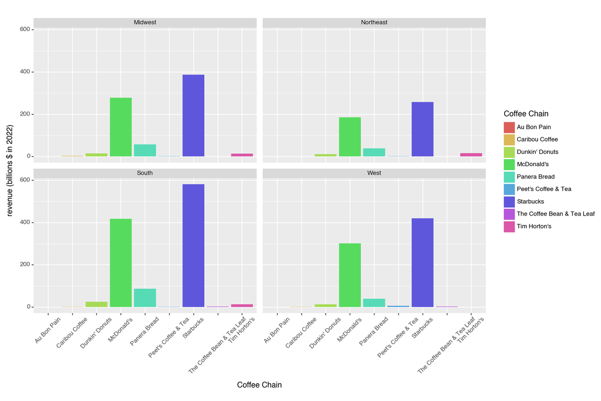

```
<Figure Size: (1200 x 800)>
```

```python
#Which coffee chain is the most popular per region?
(ggplot(coffee_inner, aes(x = "Coffee Chain", y = "revenue (billions $ in 2022)", fill = "Coffee Chain"))
 + geom_col()
 + facet_wrap("region")
 + theme(axis_text_x = element_text(rotation = 45))
 + theme(figure_size = (12,8))
)
```

In all regions, Starbucks is the most popular since it has generated the most revenue in all of the regions. The second most popular chain is McDonald’s. Starbucks is most profitable in the South.

```python
#summary statistic for which state drinks the most coffee
coffee_inner[["State", "revenue (billions $ in 2022)"]].groupby("State").mean().sort_values(by = "revenue (billions $ in 2022)", ascending = False)
```

| State | revenue (billions $ in 2022) |
| --- | --- |
| Wyoming | 27.715000 |
| Montana | 27.715000 |
| Alaska | 27.715000 |
| Idaho | 20.076667 |
| Utah | 18.943333 |
| Vermont | 15.407500 |
| Tennessee | 15.407500 |
| South Carolina | 15.407500 |
| Oklahoma | 15.407500 |
| New Mexico | 15.407500 |
| Mississippi | 15.407500 |
| Louisiana | 15.407500 |
| Alabama | 15.407500 |
| Arkansas | 15.407500 |
| North Dakota | 15.123000 |
| South Dakota | 15.123000 |
| West Virginia | 12.852000 |
| Delaware | 12.852000 |
| Washington | 12.522600 |
| Arizona | 12.426000 |
| Nebraska | 12.378400 |
| Iowa | 12.378400 |
| Kansas | 12.378400 |
| Wisconsin | 12.378400 |
| New Hampshire | 12.334200 |
| Hawaii | 11.662600 |
| Rhode Island | 10.716833 |
| Connecticut | 10.716833 |
| New Jersey | 10.716833 |
| New York | 10.716833 |
| Massachusetts | 10.716833 |
| Maine | 10.716833 |
| Kentucky | 10.716833 |
| California | 10.518833 |
| Oregon | 10.479167 |
| Colorado | 10.479167 |
| North Carolina | 10.398667 |
| Florida | 10.361833 |
| District of Columbia | 10.322167 |
| Maryland | 10.322167 |
| Virginia | 9.223286 |
| Missouri | 9.223286 |
| Ohio | 9.223286 |
| Indiana | 9.223286 |
| Minnesota | 9.223286 |
| Michigan | 9.223286 |
| Texas | 9.022000 |
| Nevada | 9.022000 |
| Illinois | 8.988000 |
| Georgia | 8.919000 |
| Pennsylvania | 8.193250 |

Seems like people in Wyoming, Montana, and Alaska drink the most coffee at the given list of coffee shops.

The financial data between region and states do not match, which is peculiar. Although these coffee shops generate the most revenue in the South region, the summary statistic shows that the states generating the most revenue for these coffee shops are Wyoming, Montana, and Alaska, which are states in the West. Let’s look at the population data and compare accordingly; this may be due to revenue per capita.

```python
coffee_inner["revenue per capita"] = coffee_inner["revenue (billions $ in 2022)"] / coffee_inner["Population"]
coffee_inner
```

|  | State | Coffee Chain | State Abbreviation | Location Count | Population | connie_abbreviation | revenue (billions $ in 2022) | region | revenue per capita |
| --- | --- | --- | --- | --- | --- | --- | --- | --- | --- |
| 0 | Alaska | Starbucks | AK | 24 | 733391 | AK | 32.25 | West | 4.397381e-05 |
| 1 | Alaska | McDonald's | AK | 33 | 733391 | AK | 23.18 | West | 3.160661e-05 |
| 2 | Alabama | Starbucks | AL | 73 | 5024279 | AL | 32.25 | South | 6.418831e-06 |
| 3 | Alabama | Dunkin' Donuts | AL | 1 | 5024279 | AL | 1.40 | South | 2.786469e-07 |
| 4 | Alabama | Panera Bread | AL | 20 | 5024279 | AL | 4.80 | South | 9.553610e-07 |
| ... | ... | ... | ... | ... | ... | ... | ... | ... | ... |
| 263 | West Virginia | Tim Horton's | WV | 7 | 1793716 | WV | 2.63 | South | 1.466230e-06 |
| 264 | West Virginia | Panera Bread | WV | 14 | 1793716 | WV | 4.80 | South | 2.676009e-06 |
| 265 | West Virginia | McDonald's | WV | 107 | 1793716 | WV | 23.18 | South | 1.292289e-05 |
| 266 | Wyoming | Starbucks | WY | 16 | 576851 | WY | 32.25 | West | 5.590698e-05 |
| 267 | Wyoming | McDonald's | WY | 34 | 576851 | WY | 23.18 | West | 4.018369e-05 |

268 rows × 9 columns

```python
coffee_inner[["State", "revenue per capita"]].groupby("State").mean().sort_values(by = "revenue per capita", ascending = False)
```

| State | revenue per capita |
| --- | --- |
| Wyoming | 4.804534e-05 |
| Alaska | 3.779021e-05 |
| Montana | 2.556204e-05 |
| Vermont | 2.395903e-05 |
| North Dakota | 1.941101e-05 |
| South Dakota | 1.705601e-05 |
| District of Columbia | 1.496953e-05 |
| Delaware | 1.298250e-05 |
| Idaho | 1.091654e-05 |
| Rhode Island | 9.765845e-06 |
| New Hampshire | 8.953859e-06 |
| Hawaii | 8.014040e-06 |
| Maine | 7.866380e-06 |
| New Mexico | 7.276194e-06 |
| West Virginia | 7.165014e-06 |
| Nebraska | 6.310668e-06 |
| Utah | 5.790207e-06 |
| Mississippi | 5.202988e-06 |
| Arkansas | 5.116180e-06 |
| Kansas | 4.213378e-06 |
| Oklahoma | 3.891419e-06 |
| Iowa | 3.879927e-06 |
| Louisiana | 3.307923e-06 |
| Alabama | 3.066609e-06 |
| South Carolina | 3.010203e-06 |
| Connecticut | 2.971991e-06 |
| Nevada | 2.905997e-06 |
| Oregon | 2.473102e-06 |
| Kentucky | 2.378434e-06 |
| Tennessee | 2.229468e-06 |
| Wisconsin | 2.100270e-06 |
| Colorado | 1.814978e-06 |
| Arizona | 1.737537e-06 |
| Maryland | 1.671004e-06 |
| Washington | 1.625197e-06 |
| Minnesota | 1.616279e-06 |
| Massachusetts | 1.524461e-06 |
| Missouri | 1.498524e-06 |
| Indiana | 1.359258e-06 |
| New Jersey | 1.153713e-06 |
| Virginia | 1.068574e-06 |
| North Carolina | 9.960993e-07 |
| Michigan | 9.152508e-07 |
| Georgia | 8.326248e-07 |
| Ohio | 7.816709e-07 |
| Illinois | 7.015020e-07 |
| Pennsylvania | 6.301191e-07 |
| New York | 5.305035e-07 |
| Florida | 4.810913e-07 |
| Texas | 3.095503e-07 |
| California | 2.660421e-07 |

As it turns out, people in states Wyoming, Montana, and Alaska go to these coffee chain shops very often. Although there are significantly less people in these states compared to states with bigger populations like Texas and California, people living in the states Wyoming, Montana, and Alaska often go to coffee chain shops to get their coffee, thus generating lots of revenue for these shops. Let us see how many locations there are per coffee shop per state.

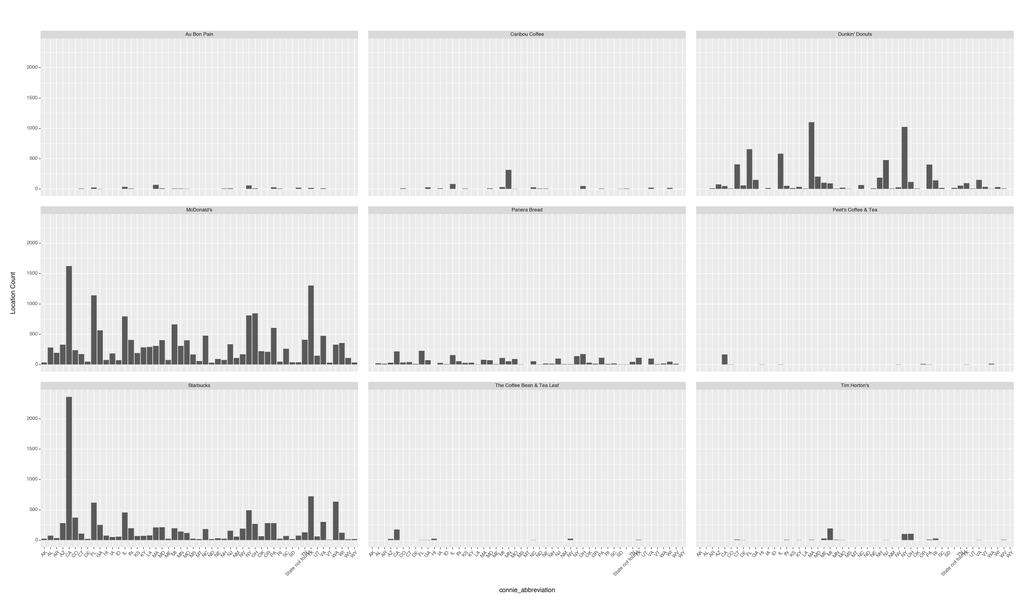

```
<Figure Size: (2500 x 1500)>
```

```python
#how many coffee shops per shop per state
(ggplot(coffee_inner, aes(x = "connie_abbreviation", y = "Location Count"))
 + geom_col()
 + facet_wrap("Coffee Chain")
 + theme(axis_text_x = element_text(rotation = 45))
 + theme(figure_size = (25, 15))
)
```

```python
# coffee_inner[["State", "Location Count"]].groupby("State").sum().sort_values(by = "Location Count", ascending = False)
state_shop_location = coffee_inner[["State", "Coffee Chain", "Location Count"]]
state_shop_location.groupby(["State", "Coffee Chain"]).sum().head(50)
```

| State | Coffee Chain | Location Count |
| --- | --- | --- |
| Alabama | Dunkin' Donuts | 1 |
|  | McDonald's | 279 |
|  | Panera Bread | 20 |
|  | Starbucks | 73 |
| Alaska | McDonald's | 33 |
|  | Starbucks | 24 |
| Arizona | Dunkin' Donuts | 74 |
|  | McDonald's | 326 |
|  | Panera Bread | 29 |
|  | Starbucks | 279 |
|  | The Coffee Bean & Tea Leaf | 19 |
| Arkansas | Dunkin' Donuts | 11 |
|  | McDonald's | 190 |
|  | Panera Bread | 13 |
|  | Starbucks | 33 |
| California | Dunkin' Donuts | 46 |
|  | McDonald's | 1623 |
|  | Panera Bread | 216 |
|  | Peet's Coffee & Tea | 163 |
|  | Starbucks | 2362 |
|  | The Coffee Bean & Tea Leaf | 175 |
| Colorado | Caribou Coffee | 9 |
|  | Dunkin' Donuts | 5 |
|  | McDonald's | 237 |
|  | Panera Bread | 32 |
|  | Peet's Coffee & Tea | 3 |
|  | Starbucks | 371 |
| Connecticut | Au Bon Pain | 8 |
|  | Dunkin' Donuts | 406 |
|  | McDonald's | 173 |
|  | Panera Bread | 41 |
|  | Starbucks | 107 |
|  | Tim Horton's | 10 |
| Delaware | Dunkin' Donuts | 57 |
|  | McDonald's | 46 |
|  | Panera Bread | 9 |
|  | Starbucks | 20 |
|  | Tim Horton's | 1 |
| District of Columbia | Au Bon Pain | 21 |
|  | Caribou Coffee | 8 |
|  | Dunkin' Donuts | 15 |
|  | McDonald's | 37 |
|  | Panera Bread | 4 |
|  | Starbucks | 72 |
| Florida | Au Bon Pain | 23 |
|  | Dunkin' Donuts | 654 |
|  | McDonald's | 1142 |
|  | Panera Bread | 227 |
|  | Starbucks | 616 |
|  | The Coffee Bean & Tea Leaf | 1 |

```python
state_shop_location.groupby(["State", "Coffee Chain"]).sum().sort_values(by = "Location Count", ascending = False).head(50)
```

| State | Coffee Chain | Location Count |
| --- | --- | --- |
| California | Starbucks | 2362 |
|  | McDonald's | 1623 |
| Texas | McDonald's | 1303 |
| Florida | McDonald's | 1142 |
| Massachusetts | Dunkin' Donuts | 1101 |
| New York | Dunkin' Donuts | 1022 |
| Ohio | McDonald's | 843 |
| New York | McDonald's | 811 |
| Illinois | McDonald's | 791 |
| Texas | Starbucks | 720 |
| Michigan | McDonald's | 662 |
| Florida | Dunkin' Donuts | 654 |
| Washington | Starbucks | 634 |
| Florida | Starbucks | 616 |
| Pennsylvania | McDonald's | 603 |
| Illinois | Dunkin' Donuts | 579 |
| Georgia | McDonald's | 563 |
| New York | Starbucks | 492 |
| New Jersey | Dunkin' Donuts | 477 |
| North Carolina | McDonald's | 475 |
| Virginia | McDonald's | 473 |
| Illinois | Starbucks | 455 |
| Tennessee | McDonald's | 409 |
| Indiana | McDonald's | 406 |
| Connecticut | Dunkin' Donuts | 406 |
| Pennsylvania | Dunkin' Donuts | 402 |
| Maryland | McDonald's | 402 |
| Missouri | McDonald's | 396 |
| Colorado | Starbucks | 371 |
| Wisconsin | McDonald's | 353 |
| New Jersey | McDonald's | 335 |
| Arizona | McDonald's | 326 |
| Washington | McDonald's | 326 |
| Minnesota | Caribou Coffee | 312 |
| Massachusetts | McDonald's | 306 |
| Minnesota | McDonald's | 305 |
| Virginia | Starbucks | 300 |
| Louisiana | McDonald's | 291 |
| Kentucky | McDonald's | 283 |
| Oregon | Starbucks | 279 |
| Arizona | Starbucks | 279 |
| Pennsylvania | Starbucks | 279 |
| Alabama | McDonald's | 279 |
| Ohio | Starbucks | 266 |
| South Carolina | McDonald's | 258 |
| Georgia | Starbucks | 248 |
| Colorado | McDonald's | 237 |
| Florida | Panera Bread | 227 |
| Oklahoma | McDonald's | 220 |
| California | Panera Bread | 216 |

California has the most number of Starbucks and McDonald’s locations. This makes sense since California has a big population and land area; it most accomodate to the number of people living in California. Wyoming, Montana, and Alaska however are not in the top 50. We may say that a high percentage of people living in Wyoming, Montana, and Alaska go to these chain coffee shops to get their coffee. Since there are very few locations opened, residents in these states must get their coffee at these limited locations only.

Another possible reason for Wyoming, Montana, and Alaska generating the most revenue out of all the states is that these states may have lots of tourists, and these coffee shops are located strategically in touristy areas. When the weather gets very cold, these tourists look forward to a hot cup of coffee, and these chain stores are the only ones available to provide.

# Automate steps 1-3

### The menuism website is down, so I am unable to test the function out.

```python
def coffee_shop(url):
    """
    Produce a clean, orgnaized dataset that has 3 columns: state abbreviation, location count, and company name after given a website to scrape from.

    Parameter
    ---------
    url: str
    The url link of the website to be scraped

    Returns
    -------
    Pandas dataframe
    Includes state abbreviation, location count, and company name.

    """
    response_shop = requests.get(url)

    soup_shop = BeautifulSoup(response_shop.content, "html.parser")

    # Finding All US Stores
    stores_shop = soup_shop.find_all("li",
                            attrs=
                             {"class": ""})

    # Creating For Loop that Goes Through Each Store
    rows_shop = []

    for store in stores_shop:

        # Adjusting for Content not containing Titles or Relevant Keys
        if store.find("a") != None:
            cells = store.find("a")

            if cells.get('title') != None:
                loc_tag = cells.get('title')

                # Filtering Just to US Locations
                if loc_tag[-2:] == "us" and loc_tag[-6:-4] != "dc":

                  # Find the name of the State
                    store_tag = cells.get_text()

                  # Creating List of Store Tag to Obtain State Name
                    tag_list = store_tag.split(" ")

                    states_list = ['Dakota','Carolina','Hampshire','York','Jersey','Mexico','Island','Virginia']
                    if tag_list[1] not in states_list:
                        state_name = tag_list[0]

                    else:
                        state_name = " ".join(tag_list[0:2])

                    store_locations = re.findall(r'\((.*?)\)', store_tag)[0] # Locations In Between Parentheses
                    store_locations = pd.to_numeric(store_locations) # Converting to Integers

                  # Obtaining Store Name from URL
                    pattern = r'/([^/]+)$'
                    store_name = re.findall(pattern, url_dd)[0]

                  # Append this data.
                    rows_shop.append({
                        "State": state_name,
                        store_name:store_locations
                    })

    # Converting Rows to Dataframe
    shop_df = pd.DataFrame(rows_shop)

    #apply abbreviation function to get state abbreviations
    shop_state_df = shop_df.apply(lambda x: stateabbr(x["State"]), axis=1)

    return shop_state_df
```